# Q2_Starter_Code (1)

## Clean Water Project Instructions

1. Download CleanWaterDataSet.rar from the shared box and Unpack it.
2. Upload the entire folder to your google drive.
3. Click File > Save a Copy in Drive and work on your own saved notebook.
4. Instructions for coding (What you need to code):
- Set DATA_PATH and FOLDER_PATH to your paths of CleanWaterDataset and CleanWaterProject, respectively.
- Define your training model in the section of Training. The network structure will affect the model’s accuracy. Try different structures of the network to improve the performance. Run the cell of Training Routine to train the model. Keep in mind that batch_size and epochs will also affect the prediction accuracy, and batch_size is also related to the size of the input image. Try to tune them as well. The trained model will be saved to cleanwaterai.h5.
- Test you model: run the cell of Test to see how your model preform via visualizing 20 test images.
- Print your notebook by clicking File > Save > PDF to upload your work.

# Import necessary libraries

```python
import tensorflow as tf
from tensorflow.keras.models import Sequential, load_model
from tensorflow.keras.layers import Conv2D, MaxPool2D, Flatten, Dropout, Dense
from tensorflow.keras.losses import categorical_crossentropy
from tensorflow.keras.utils import to_categorical
from tensorflow.keras.optimizers import SGD
import pathlib
import cv2
import matplotlib.pyplot as plt
import numpy as np
import os

plt.style.use('ggplot')
```

# Global Settings

```python
DATA_DIR = 'Q2 - Clean Water AI'
SAVE_DIR = 'CleanWaterProject'
```

```python
IMAGE_WIDTH = 50
IMAGE_HEIGHT = 50
TRAIN_SIZE = 770
TEST_SIZE = 330
```

# Load Data

```python
def load_data(folder):
    train_x = np.load(pathlib.Path(folder)/'train_input.npy')/255
    train_y_idx = np.load(pathlib.Path(folder)/'train_label.npy')
    train_y = to_categorical(train_y_idx, 11)
    test_x = np.load(pathlib.Path(folder)/'test_input.npy')/255
    test_y_idx = np.load(pathlib.Path(folder)/'test_label.npy')
    test_y = to_categorical(test_y_idx, 11)

    return train_x, train_y_idx, train_y, test_x, test_y_idx, test_y
```

# Load Dataset

```python
train_x, train_y_idx, train_y, test_x, test_y_idx, test_y = load_data(DATA_DIR)
```

# Visualize Dataset

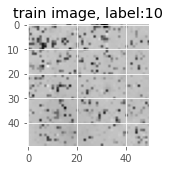

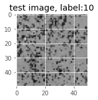

```python
# Visualize Dataset
index = 0
plt.figure(figsize=(3, 2.25))
img = train_x[index, :, :].astype(int)
plt.imshow(img, cmap='gray')
plt.title('train image, label:{}'.format(int(train_y_idx[index])))
plt.show()
plt.figure(figsize=(3, 2.25))
img = test_x[index, :, :].astype(int)
plt.imshow(img, cmap='gray')
plt.title('test image, label:{}'.format(int(test_y_idx[index])))
plt.show()
```

# Define Model

```python
model = Sequential([
    Conv2D(128, (3, 3), input_shape=(50,50,1), activation="relu"),
    MaxPool2D(2,2),
    Conv2D(64,(3,3), activation="relu"),
    MaxPool2D(2,2),
    Conv2D(32,(3,3), activation="relu"),
    Flatten(),
    Dense(11),
    tf.keras.layers.Activation('softmax')
])
```

# Print Model Summary

```python
model.summary()
```

```
Model Summary
Model: "sequential"
_________________________________________________________________
 Layer (type)                Output Shape              Param #
=================================================================
 conv2d (Conv2D)             (None, 48, 48, 128)       1280

 max_pooling2d (MaxPooling2D  (None, 24, 24, 128)      0
 )

 conv2d_1 (Conv2D)           (None, 22, 22, 64)        73792

 max_pooling2d_1 (MaxPooling  (None, 11, 11, 64)       0
 2D)

 conv2d_2 (Conv2D)           (None, 9, 9, 32)          18464

 flatten (Flatten)           (None, 2592)              0

 dense (Dense)               (None, 11)                28523

 activation (Activation)     (None, 11)                0

=================================================================
Total params: 122,059
Trainable params: 122,059
Non-trainable params: 0
_________________________________________________________________
```

# Compile Model

```python
opt = SGD(momentum=.9)
model.compile(loss='categorical_crossentropy', optimizer=opt, metrics=['accuracy'])
```

# Train Model

```python
model.fit(train_x, train_y, batch_size=512, epochs=1000)
```

[output not shown]

```
<keras.callbacks.History at 0x1f188558820>
```

# Save Model

```python
model.save(os.path.join(SAVE_DIR,'Clean_Water_Model'))
```

# Evaluate the model on the test set

```python
test_loss, test_accuracy = model.evaluate(test_x, test_y, verbose=2)
print('Test loss: {:.4f}'.format(test_loss))
print('Test accuracy: {:.4f}'.format(test_accuracy))
```

```
11/11 - 1s - loss: 0.2316 - accuracy: 0.9515 - 939ms/epoch - 85ms/step
Test loss: 0.2316
Test accuracy: 0.9515
```

# Make predictions on 20 random samples from the test set

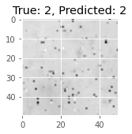

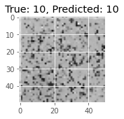

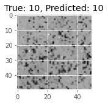

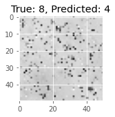

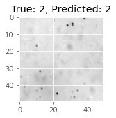

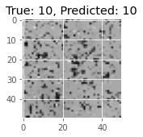

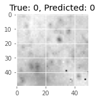

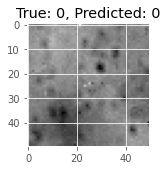

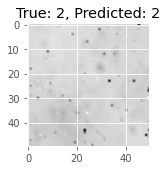

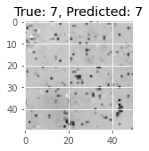

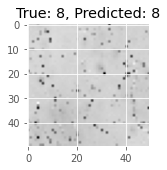

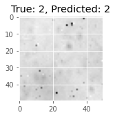

[8 more figures not shown]

```python
sample_indices = np.random.choice(len(test_x), 20)
for i in range(len(sample_indices)):
    index = sample_indices[i]
    pred_one_hot = model.predict(np.reshape(test_x[index, :, :, :], (1, IMAGE_HEIGHT, IMAGE_WIDTH, 1)))
    pred = np.argmax(pred_one_hot)
    plt.figure(figsize=(3, 2.25))
    img = test_x[index, :, :].astype(int)
    plt.imshow(img, cmap='gray')
    plt.title('True: {}, Predicted: {}'.format(int(test_y_idx[index]), pred))
    plt.show()
```